# ETC3250 ASSIGNMENT 4

Jia Lin Gao (25982990), Yang Wang (28463293), Alicia Lam (29676088), Tarushi Hondhe-Munige-Leader (28768361)

17/05/2020

## Exercises

### 1.

Here we explore the maximal margin classifier on a toy data set.

| id | x1 | x2 | class |
| --- | --- | --- | --- |
| 1 | 2 | 4 | -1 |
| 2 | 4 | 2 | -1 |
| 3 | 1 | 5 | -1 |
| 4 | 4 | 4 | -1 |
| 5 | 3 | 3 | -1 |
| 6 | 4 | 3 | -1 |
| 7 | 2 | 5 | -1 |
| 8 | 5 | 3 | -1 |
| 9 | 3 | 1 | 1 |
| 10 | 1 | 3 | 1 |
| 11 | 1 | 1 | 1 |
| 12 | 2 | 1 | 1 |
| 13 | 0 | 2 | 1 |
| 14 | 1 | 2 | 1 |
| 15 | 0 | 3 | 1 |

1. We are given $n = 15$ observations in $p = 2$ dimensions. For each observation, there is an associated class label. Sketch the observations.

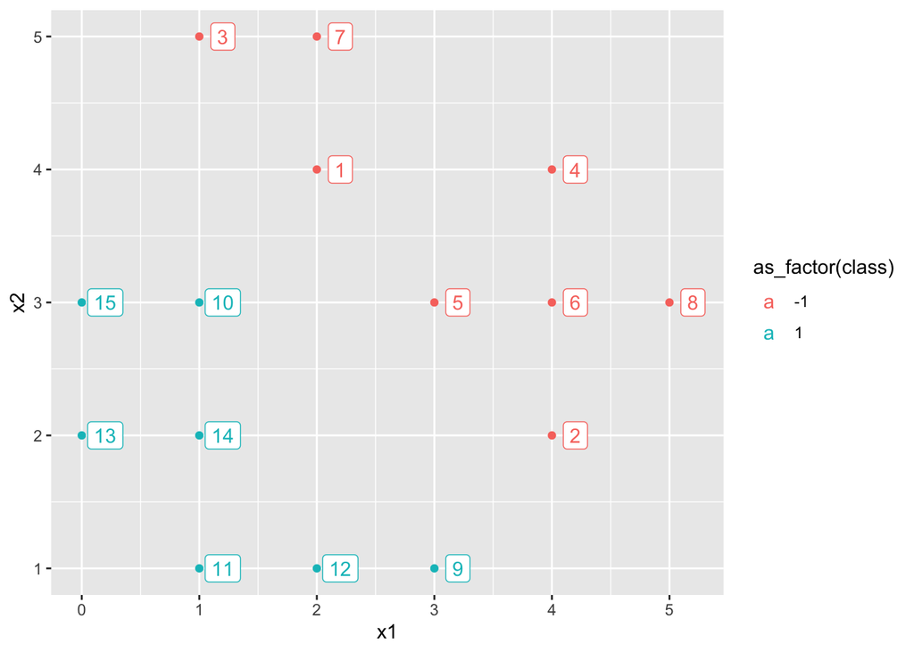

2. Sketch the optimal separating hyperplane, and provide the equation for this hyperplane in the form of textbook equation 9.1.

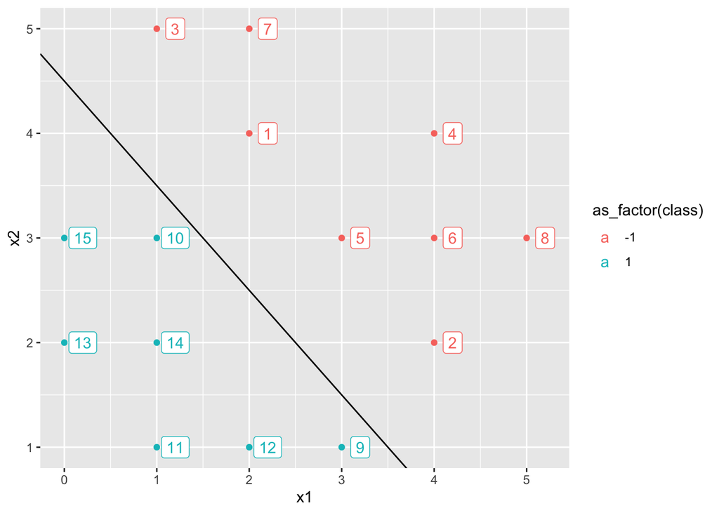

$$\beta_0 +\beta_1 X_1 + \beta_2 X_2 = 0$$

$$4.5 - X_1 - X_2 = 0$$

3. Write the classification rule for the maximal margin classifier.

$$\beta_0 + \beta_1 X_1 + \beta_2 X_2 > 0\ if Y_i = 1$$

$$-4.5995 - 0.7991 X_1 - 1.1999 X_2 < 0\ if\ Y_i = 1$$

4. On your sketch, indicate the margin for the maximal margin hyperplane.

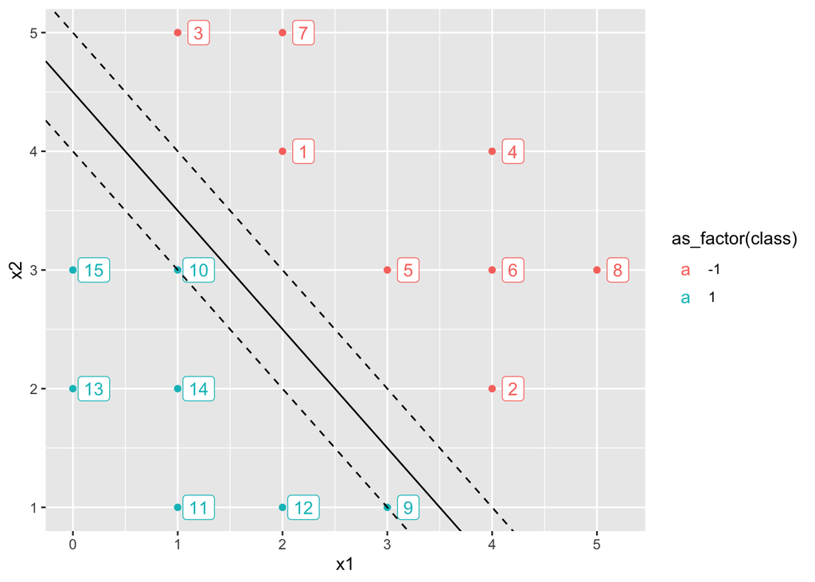

- The margin is the distance between the classifier line to the dashed lines
5. Indicate the support vectors for the maximal margin classifier.

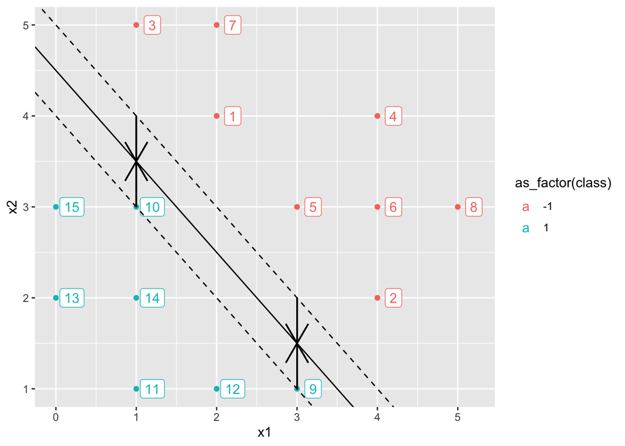

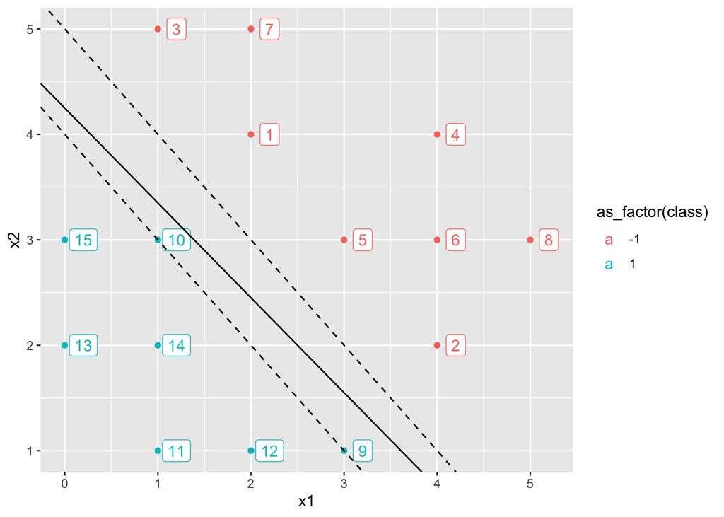

8. How would the separating hyperplane change if an 8th observation (16, 2, 2.5, 1) as added to the data?

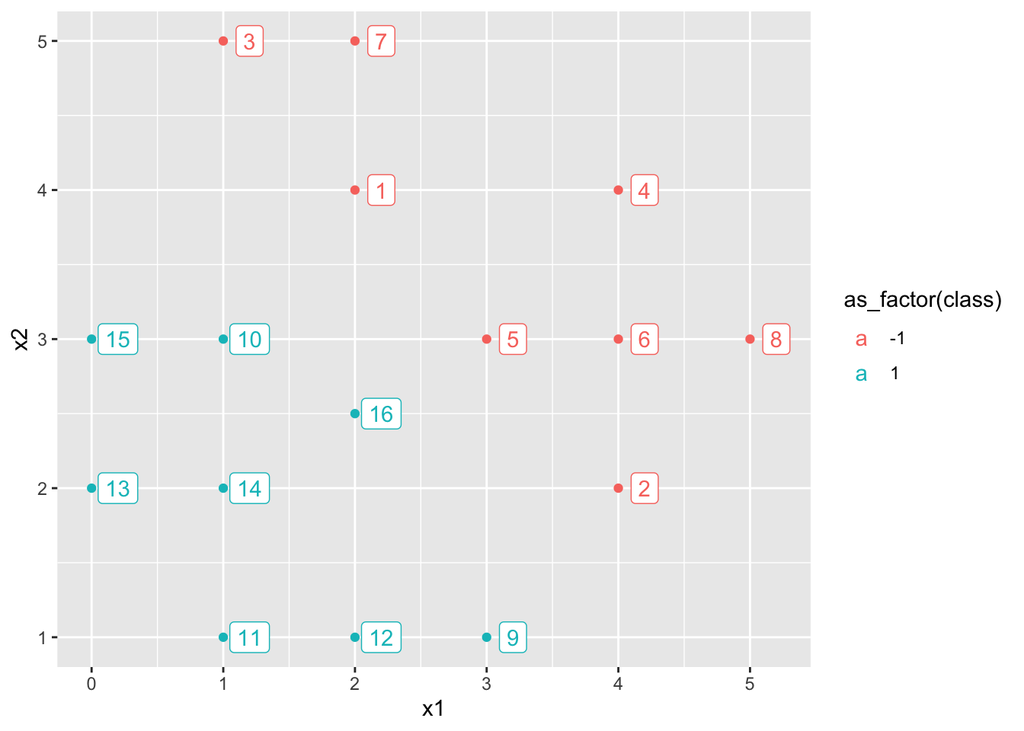

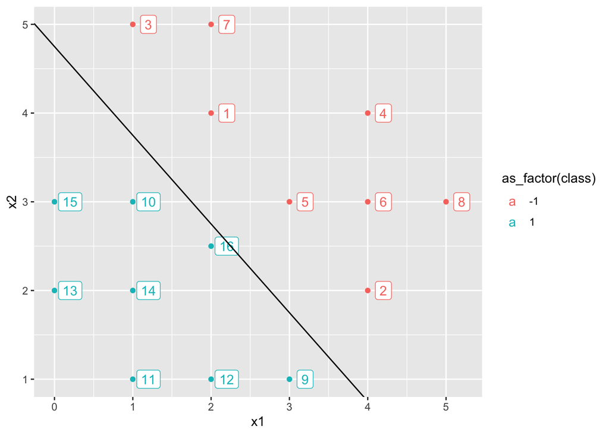

Using gaussian elimination on the three nearest points (2, 3, 16) in matrix form
$$\begin{bmatrix} 1 & 2 & 2.5 & M \\ -1 & -3 & -2 & M \\ -1 & -1 & -4& M \end{bmatrix}$$

Reduces to

$$\begin{bmatrix} 1 & 2 & 2.5 & M \\ 0 & -1 & 0.5 & M \\ 0 & 0 & -1& 4M \end{bmatrix}$$

Which yields

$$\beta_0=19M, \beta_1 = -4M, \beta_2 = -4M$$

Subject to

$$\sum{\beta_j^2 = 1}$$

And the classification equation is

$$y_i(19M - 4Mx_i - 4Mx_i2) > 0$$

- The intercept of the hyperplane has to be changed from the previous optimal hyperplane, as there is a new interception at the new observation.
1. Using the `svm` function of the `e1071` package fit the linear svm model to this data. Compare the result with your hand calculation.

```
## # A tibble: 16 x 4
##       id    x1    x2 class
##    <dbl> <dbl> <dbl> <fct>
##  1     1     2   4   -1
##  2     2     4   2   -1
##  3     3     1   5   -1
##  4     4     4   4   -1
##  5     5     3   3   -1
##  6     6     4   3   -1
##  7     7     2   5   -1
##  8     8     5   3   -1
##  9     9     3   1   1
## 10    10     1   3   1
## 11    11     1   1   1
## 12    12     2   1   1
## 13    13     0   2   1
## 14    14     1   2   1
## 15    15     0   3   1
## 16    16     2   2.5 1
```

```
##
## Call:
## svm(formula = class ~ x1 + x2, data = df_mod, kernel = "linear",
##     type = "C-classification", scale = FALSE)
##
##
## Parameters:
##    SVM-Type:  C-classification
##  SVM-Kernel:  linear
##        cost:  1
##
## Number of Support Vectors:  6
```

```
##
## Call:
## svm(formula = class ~ x1 + x2, data = df_mod, kernel = "linear",
##     type = "C-classification", scale = FALSE)
##
##
## Parameters:
##    SVM-Type:  C-classification
##  SVM-Kernel:  linear
##        cost:  1
##
## Number of Support Vectors:  6
##
##  ( 3 3 )
##
##
## Number of Classes:  2
##
## Levels:
##  -1 1
```

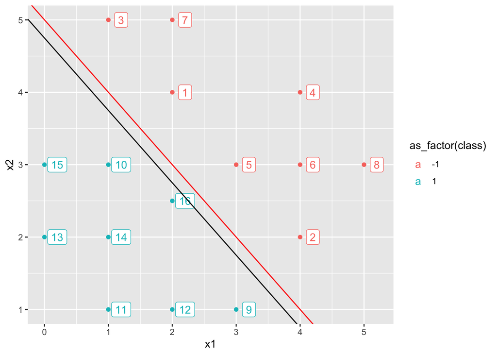

### 2.

Use the `Caravan` data from the `ISLR` package. Read the data description.

1. Compute the proportion of caravans purchased relative to not purchased. Is this a balanced class data set? What problem might be encountered in assessing the accuracy of the model as a consequence?

```
## # A tibble: 2 x 2
##   Purchase     n
##   <fct>    <int>
## 1 No        5474
## 2 Yes        348
```

```
##   sum(Purchase == 1)
## 1         0.05641422
```

```
##   sum(Purchase == 1)
## 1         0.06649485
```

4. The solution code on the unofficial solution web site:

```
library(ISLR)
train = 1:1000
Caravan$Purchase = ifelse(Caravan$Purchase == "Yes", 1, 0)
Caravan.train = Caravan[train, ]
Caravan.test = Caravan[-train, ]
```

would use just the first 1000 cases for the training set. What is wrong about doing this?

- By using only the first 1000 cases, there is no randomisation in the sample obtained, and therefore an accurate training set that represents the overall dataset is not obtained.
- However, when checking with the code below, there are 59 purchases which are in the first 1000 entries, which shows that this is similar to the proportion of purchases in the entire dataset.

```
## # A tibble: 1 x 2
##   `sum(Purchase == 1)`     n
##                  <int> <int>
## 1                   59  1000
```

### 3.

Here we will fit a boosted tree model, using the `gbm` package.

1. Use 1000 trees, and a shrinkage value of 0.01.

```
##               var   rel.inf
## PPERSAUT PPERSAUT 21.094065
## PPLEZIER PPLEZIER 16.068942
## PBRAND     PBRAND  9.092745
## MKOOPKLA MKOOPKLA  5.812220
## PBYSTAND PBYSTAND  5.677474
## MOPLHOOG MOPLHOOG  4.501625
```

2. Make a plot of the oob improvement against iteration number. What does this suggest about the number of iterations needed? Why do you think the oob improvement value varies so much, and can also be negative?

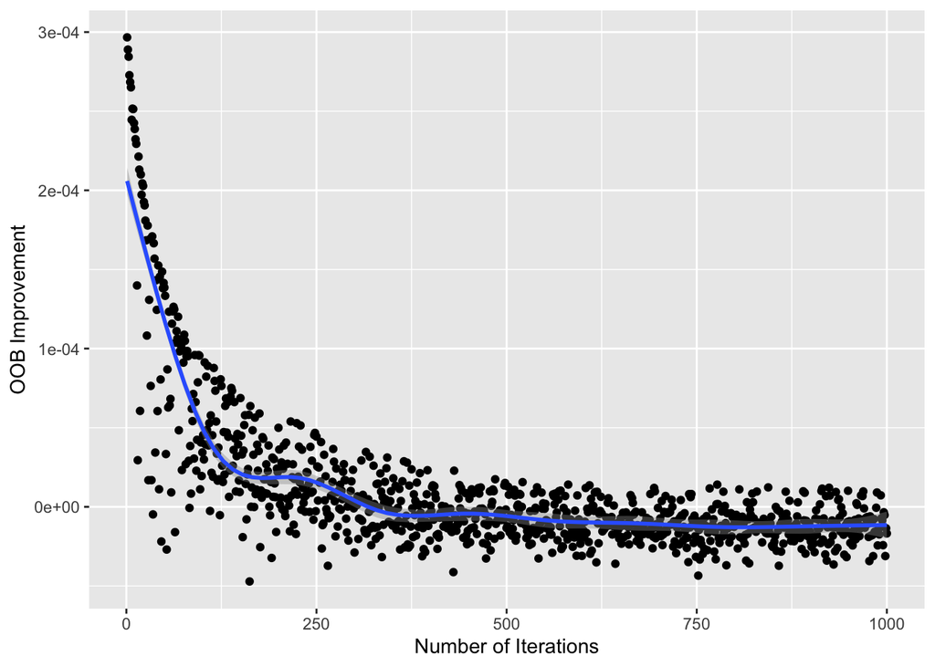

- At approximately 500 iterations, the out of bag (OOB) improvement plateaus. This showcases that only 500 iterations are needed for the maximum accuracy of the prediction model to be reached.
- OOB improvement values can be negative. This would occur if the model was overfitted for the training set, there would be an increase in misclassifications in the test set, therefore resulting in negative OOB-improvement values.
3. Compute the error for the test set, and for each class. Consider a proportion 0.2 or greater to indicate that the customer will purchase a caravan.

```
##      boost.pred
##          0    1  Sum
##   0   1757   54 1811
##   1    111   18  129
##   Sum 1868   72 1940
```

> The boosted tree model suggested that the following six variables are most important, with the attached relative importance figures.

[output not shown]

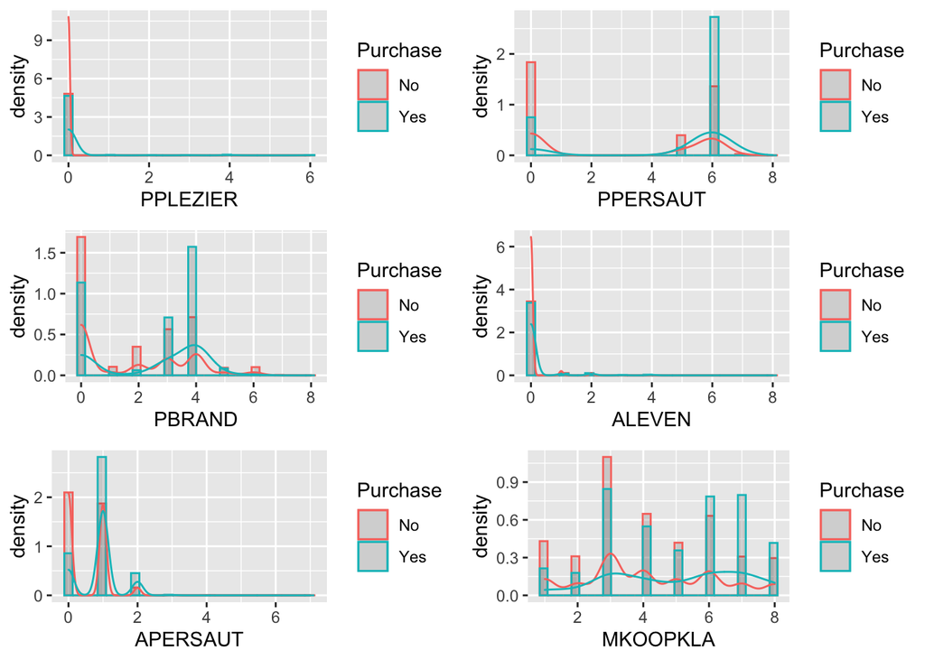

- People who purchase caraven policies are more likely to have contributions for car, fire and boat policies. They have more life and car policies and they tend to be slightly more well off than the average insurance customer *in this sample*.

### 4.

Here we will fit a random forest model, using the `randomForest` package.

1. Use 1000 trees, using a numeric response so that predictions will be a number between 0-1, and set `importance=TRUE`. (Ignore the warning about not having enough distinct values to use regression.)
2. Compute the error for the test set, and for each class. Consider a proportion 0.2 or greater to indicate that the customer will purchase a caravan.

```
##      rf.pred
##          0    1  Sum
##   0   1655  156 1811
##   1    101   28  129
##   Sum 1756  184 1940
```

3. What are the 6 most important variables? Make a plot of any that are different from those chosen by `gbm`. How does the set of variables compare with those chosen by `gbm`.

```
## # A tibble: 85 x 3
##   `%IncMSE` IncNodePurity var
##       <dbl>         <dbl> <chr>
## 1  0.00357           6.77 MOSTYPE
## 2  0.00127           6.16 PBRAND
## 3  0.00197           5.42 PPERSAUT
## 4  0.000659          4.59 APERSAUT
## 5  0.00271           4.34 MKOOPKLA
## 6  0.00173           3.90 MOPLHOOG
## # … with 79 more rows
```

[output not shown]

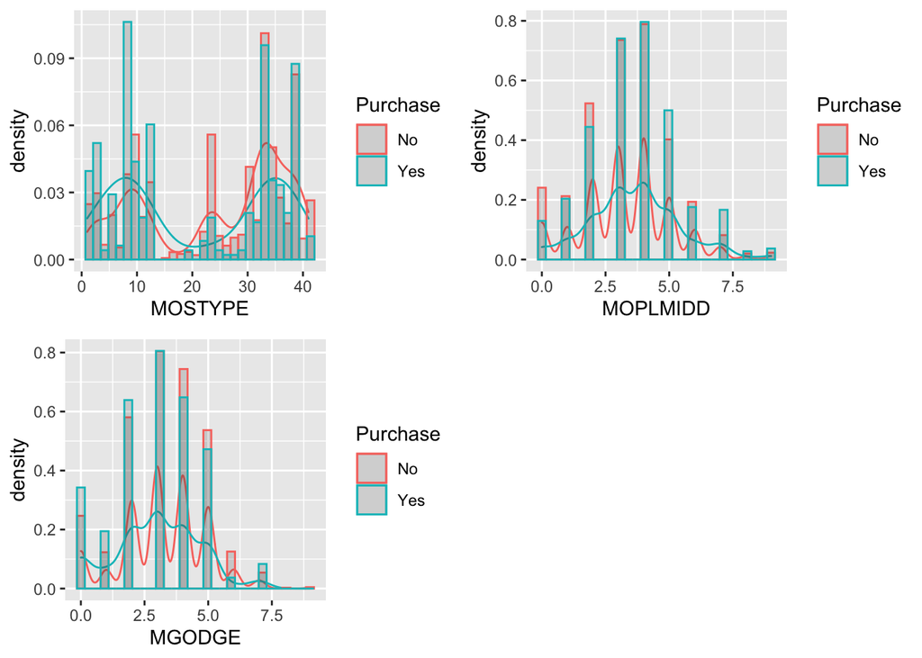

### 5.

Here we will fit a gradient boosted model, using the `xgboost` package.

1. Read the description of the XGBoost technique at https://www.hackerearth.com/practice/machine-learning/machine-learning-algorithms/beginners-tutorial-on-xgboost-parameter-tuning-r/tutorial/, or other sources. Explain how this algorithm might differ from earlier boosted tree algorithms.
2. Tune the model fit to determine how many iterations to make. Then fit the model, using the parameter set provided.

```
## Multiple eval metrics are present. Will use test_error for early stopping.
## Will train until test_error hasn't improved in 20 rounds.
##
## Stopping. Best iteration:
```

```
## ##### xgb.cv 5-folds
##  iter train_error_mean train_error_std test_error_mean test_error_std
##     1        0.0521636     0.003052849       0.0618204     0.01357279
##     2        0.0515202     0.003068609       0.0595024     0.01500123
##     3        0.0512626     0.002975865       0.0602756     0.01418359
##     4        0.0517778     0.002548311       0.0595028     0.01341517
##     5        0.0508762     0.003103604       0.0600182     0.01304461
##     6        0.0506184     0.003293327       0.0595048     0.01362122
##     7        0.0506186     0.003319755       0.0592486     0.01260298
##     8        0.0494592     0.003891643       0.0602800     0.01350886
##     9        0.0488796     0.003283535       0.0610526     0.01404309
##    10        0.0477848     0.003194790       0.0602800     0.01358244
##    11        0.0474626     0.003544233       0.0602800     0.01343494
##    12        0.0467540     0.003639607       0.0607954     0.01418162
##    13        0.0458526     0.003399852       0.0613104     0.01323999
```

[output cut: 18 more lines]

```
## [1] Inf
```

2. Compute the error for the test set, and for each class. Consider a proportion 0.2 or greater to indicate that the customer will purchase a caravan.

```
##      xgbpred
##          0    1  Sum
##   0   1516  295 1811
##   1     67   62  129
##   Sum 1583  357 1940
```

3. Compute the variable importance. What are the 6 most important variables? Make a plot of any that are different from those chosen by `gbm` or `randomForest`. How does the set of variables compare with the other two methods.

```
##     Feature       Gain      Cover  Frequency
## 1: PPERSAUT 0.19844246 0.20811732 0.03921569
## 2: PPLEZIER 0.07298859 0.10180885 0.05882353
## 3:   PBRAND 0.06406486 0.06348905 0.04901961
## 4: MOPLHOOG 0.05688963 0.03035254 0.03921569
## 5:  MOSTYPE 0.05549555 0.02152384 0.04901961
## 6: MKOOPKLA 0.04699039 0.03474223 0.03921569
```

[output not shown]

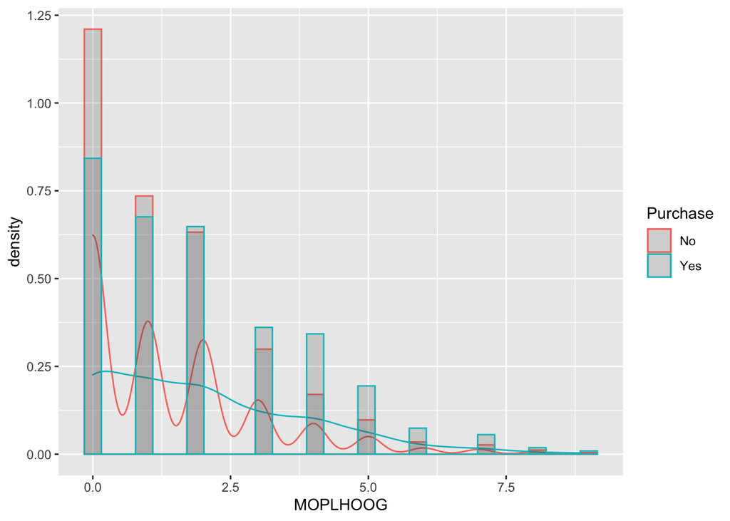

- This set of variables reveals an increased likelihood of caravan insurerers having a higher level of high level education. The most important variables for each of the three methods are tabulated here:

### 6. Compare and summarise the results of the three model fits.

[output not shown]

### 7.

Now scramble the response variable (Purchase) using permutation. The resulting data has no true relationship between the response and predictors. Re-do Q5 with this data set. Write a paragraph explaining what you learn about the true data from analysing this permuted data.

##### Break the data into 2/3 training and test set, ensuring that the same ratio of the response variable is achieved in both sets. Check that your sampling has produced this.

[output not shown]

[output cut: 38 more lines]

##### Tune the model fit to determine how many iterations to make. Then fit the model, using the parameter set provided.

```
## Multiple eval metrics are present. Will use test_error for early stopping.
## Will train until test_error hasn't improved in 20 rounds.
##
## Stopping. Best iteration:
```

##### Compute the error for the test set, and for each class. Consider a proportion 0.2 or greater to indicate that the customer will purchase a caravan.

```
##      xgbpred
##          1  Sum
##   0   1811 1811
##   1    129  129
##   Sum 1940 1940
```

```
##      xgbpred
##          0    1  Sum
##   0   1715   96 1811
##   1     99   30  129
##   Sum 1814  126 1940
```

- Using a higher probability threshold to give us more comprable results still gives us better results than the real data.

### References

https://machinelearningmastery.com/what-is-imbalanced-classification/